# Администрирование системных подсистем

Настройка и проверка работы SMTP-сервера Postfix

Сейдалиев Тагиетдин Ровшенович

Российский университет дружбы народов, Москва, Россия

30 ноября 2025

# Цель работы

## Основная цель

Приобрести навыки установки, конфигурирования и диагностики SMTP-сервера Postfix и настройки DNS для доставки почты.

# Подготовка и запуск Postfix

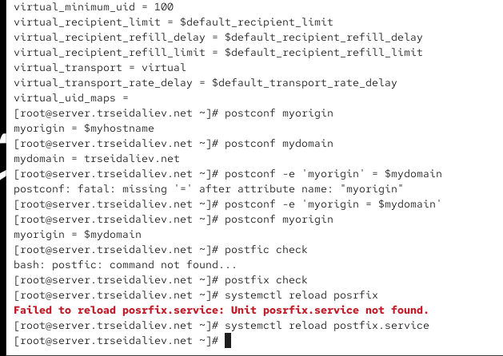

## Настройка myorigin и домена

В Postfix настраиваются параметры myorigin и mydomain для использования собственного домена.

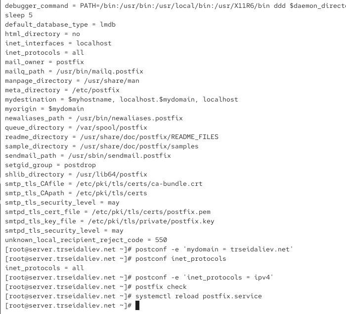

Настройка myorigin и проверка Postfix

# Проверка локальной доставки на сервере

## Отправка и мониторинг

Для проверки локальной доставки отправляется тестовое письмо и анализируется журнал maillog.

## Локальная доставка в журнале

Журнал maillog показывает успешную доставку локального письма в почтовый ящик.

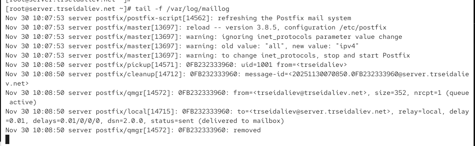

Мониторинг доставки письма на сервере

## Содержимое почтового ящика

В каталоге `/var/spool/mail` видно сохранённое локальное письмо пользователя.

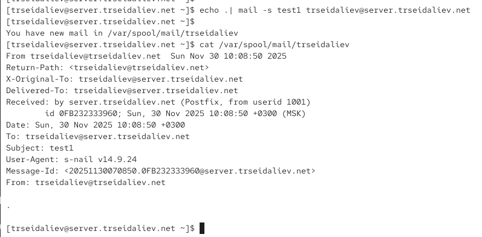

Содержимое почтового ящика на сервере

# Настройка и проверка клиента

## Установка Postfix на клиенте

На клиентской машине выполняется установка и запуск Postfix с использованием IPv4.

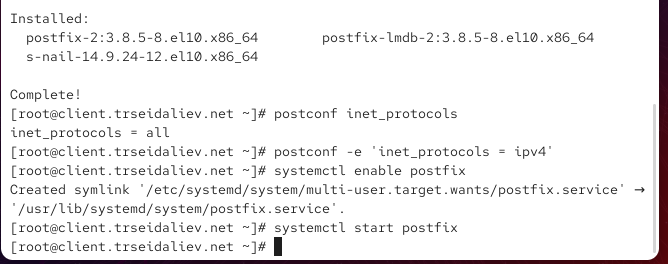

Установка и запуск Postfix на клиенте

## Сетевые параметры сервера

На сервере настраиваются inet_interfaces и mynetworks для приёма почты от клиента.

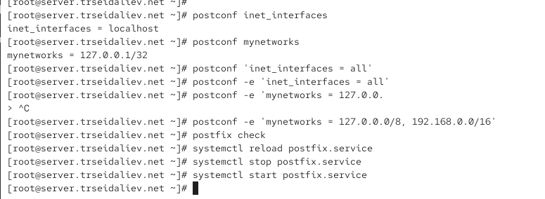

Настройка сетевых параметров и перезапуск Postfix на сервере

## Лог доставки письма от клиента

Журнал подтверждает, что письмо от клиента успешно принято и доставлено.

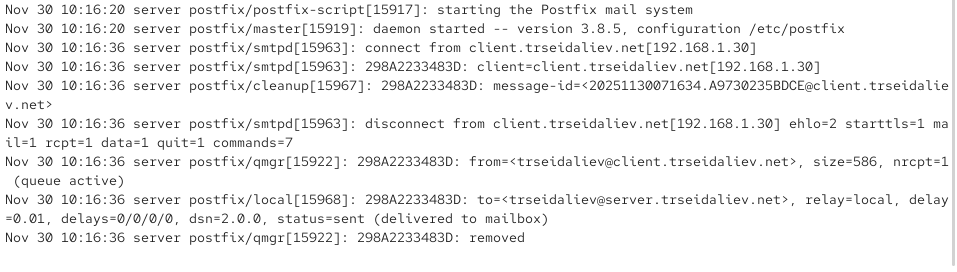

Журнал доставки письма от клиента

## Почтовый ящик после письма клиента

В почтовом ящике сервера видно доставленное письмо, отправленное с клиентской машины.

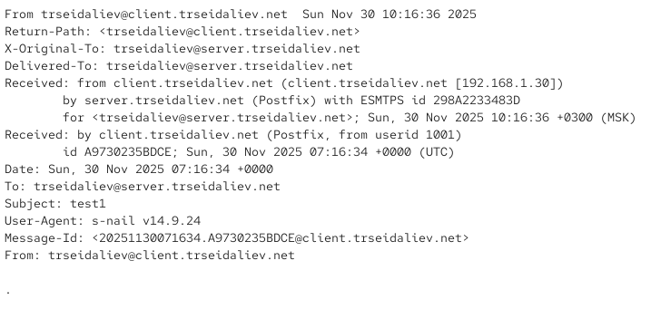

Содержимое доставленного письма от клиента

# Настройка для домена

## Ошибка из-за отсутствия маршрута

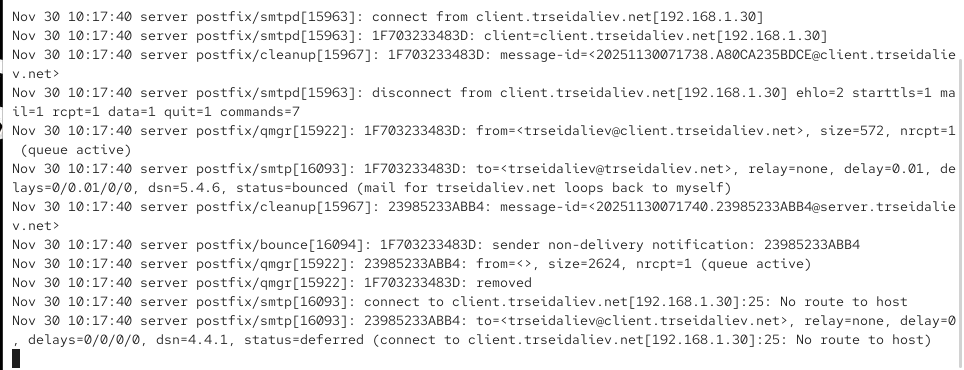

Журнал доставки с ошибкой

## Сообщение в очереди

Неудачно доставленное письмо остаётся в очереди Postfix на клиенте.

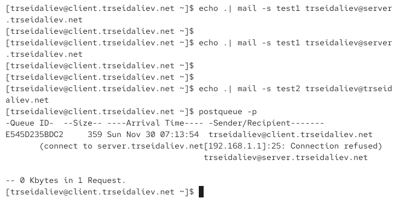

Очередь сообщений на клиенте

## Прямая DNS-зона

В прямой DNS-зоне добавляется MX-запись и A-записи для почтового сервера и узлов.

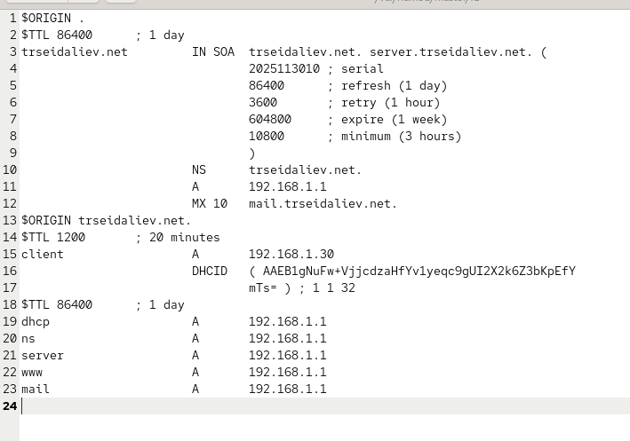

Прямая DNS-зона

## Обратная DNS-зона

В обратной DNS-зоне настраиваются PTR-записи для всех хостов, включая почтовый сервер.

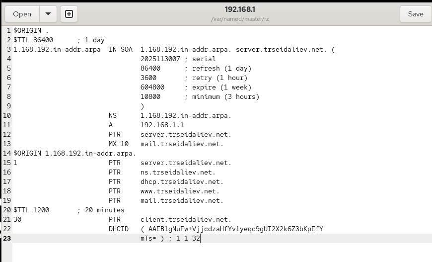

Обратная DNS-зона

## Обновление mydestination и служб

В Postfix домен добавляется в mydestination, восстанавливаются SELinux-контексты и перезапускаются службы.

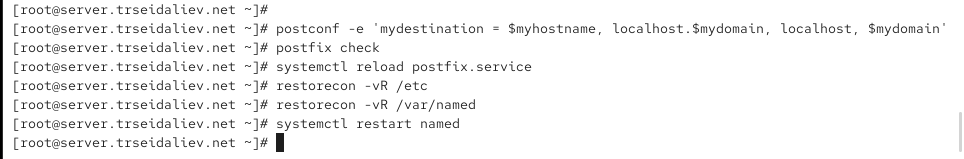

Настройка mydestination и восстановление контекстов

## Лог успешной доставки доменной почты

После исправлений журнал фиксирует успешную доставку письма на доменный адрес.

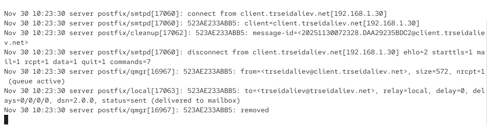

Журнал успешной доставки

## Почтовый ящик после исправления

В почтовом ящике пользователя появляется письмо, доставленное на доменный адрес.

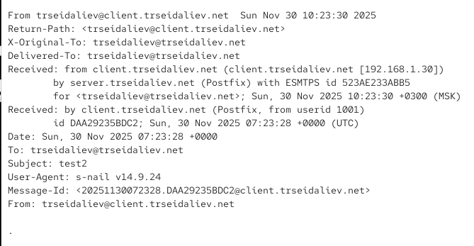

Полученное письмо после исправления конфигурации

# Итоги работы